# W04-1: Reflection on Logistic Regression and Ch8 (Preprocessing with Recipes)

Author

Tim Arana

Published

July 1, 2026

library(tidymodels)

# 1 Introduction

This report reflects on logistic regression fundamentals and preprocessing with recipes. The report includes responses to video quizzes, logarithm assignments, and coding exercises related to data splitting, preprocessing, and recipe workflows.

**Note**

This report is organized according to the assignment prompts and includes written responses, code exercises, and an appendix with GitHub links.

# Overview

This quiz covers four StatQuest videos that build the conceptual foundation for logistic regression — the model you fitted in the Week 2 notebook. Answer each question after watching the corresponding video.

| Step | Video | Link |
| --- | --- | --- |
| 1-1 | Logs (Logarithms), Clearly Explained!!! | https://www.youtube.com/watch?v=VSi0Z04fWj0 |
| 1-2 | Odds and Log(Odds), Clearly Explained!!! | https://www.youtube.com/watch?v=ARfXDSkQf1Y |
| 1-3 | Odds Ratios and Log(Odds Ratios), Clearly Explained!!! | https://www.youtube.com/watch?v=8nm0G-1uJzA |
| 2-1 | Logistic Regression, Clearly Explained!!! | https://www.youtube.com/watch?v=yIYKR4sgzI8 |

```r
library(tidyverse)

# Recreate the direct-mail dataset used throughout the course
set.seed(123)
n <- 3000

mail_data <- tibble(
  customer_id = paste0("C", str_pad(1:n, 5, pad = "0")),
  age = round(rnorm(n, mean = 45, sd = 12)),
  income = round(rlnorm(n, meanlog = 10.8, sdlog = 0.6)),
  recency_days = round(rexp(n, rate = 1 / 60)),
  freq_12mo = rpois(n, lambda = 3),
  avg_order_amt = round(rlnorm(n, meanlog = 4.2, sdlog = 0.5), 2),
  channel = sample(
    c("email", "direct_mail", "digital"),
    n,
    replace = TRUE,
    prob = c(0.5, 0.3, 0.2)
  ),
  region = sample(
    c("West", "South", "Midwest", "Northeast"),
    n,
    replace = TRUE
  ),
  loyalty_tier = sample(
    c("Bronze", "Silver", "Gold", "Platinum"),
    n,
    replace = TRUE,
    prob = c(0.4, 0.3, 0.2, 0.1)
  ),
  responded = rbinom(
    n,
    1,
    prob = plogis(
      -3 +
        0.02 * (age - 45) +
        0.3 * log(income / 50000) +
        0.1 * freq_12mo -
        0.005 * recency_days
    )
  )
) |>
  mutate(
    income = if_else(runif(n) < 0.08, NA_real_, income),
    avg_order_amt = if_else(runif(n) < 0.05, NA_real_, avg_order_amt),
    responded = factor(responded, levels = c(1, 0), labels = c("yes", "no"))
  )
```

# 2 Step 1-1 — Logarithms

> **Video:** Logs (Logarithms), Clearly Explained!!! https://www.youtube.com/watch?v=VSi0Z04fWj0

## 2.1 Q1 — What Does a Log Do?

The video says the core job of a logarithm is to **isolate the exponent**.

1. Complete the statement: “If $2^5 = 32$, then $\log_2(32) =$ ____ because…”
2. Verify in R: `log(32, base = 2)`
3. Why is this property useful when income values range from $7,000 to $455,000 in your dataset?

```r
log(32, base = 2)
```

```
[1] 5
```

## 2.2 Q2 — Multiplication Becomes Addition

The video demonstrates: $\log(a \times b) = \log(a) + \log(b)$.

1. Verify using `a = 4`, `b = 8` (base 2) — compute both sides and confirm they are equal
2. In logistic regression, we multiply many small probabilities together. Explain in one sentence why the log property above makes this computationally safer.

```r
log(4 * 8, base = 2)
```

```
[1] 5
```

```r
log(4, base = 2) + log(8, base = 2)
```

```
[1] 5
```

## 2.3 Q3 — Geometric Mean in Marketing

The video shows the geometric mean is better than the arithmetic mean for data that **multiplies** rather than adds.

Five customers’ order values: $10, $20, $80, $40, $1,000.

1. Compute the arithmetic mean with `mean()`
2. Compute the geometric mean: `exp(mean(log(x)))`
3. Which better represents the “typical” customer — and why does the $1,000 order distort the arithmetic mean more?

```r
orders <- c(10, 20, 80, 40, 1000)
mean(orders)
```

```
[1] 230
```

```r
exp(mean(log(orders)))
```

```
[1] 57.708
```

### 2.3.1 Response

1. The arithmetic mean is much larger because it is heavily influenced by the $1,000 purchase.
2. The geometric mean provides a better estimate of the typical customer because it reduces the impact of extreme values.
3. The $1,000 order is an outlier that pulls the arithmetic mean upward, while the geometric mean is less sensitive to unusually large values.

## 2.4 Q4 — Log(0) and the Offset

The video explains $\log(0)$ is undefined (negative infinity).

1. Run `log(0)` — what does R return?
2. Your Week 2 recipe uses `step_log(..., offset = 1)`. Explain in one sentence why this offset is necessary.
3. What is `log(0 + 1)`? Why is adding 1 a safe lower bound?

```r
log(0)
```

```
[1] -Inf
```

```r
log(0 + 1)
```

```
[1] 0
```

### 2.4.1 Response

1. Running `log(0)` in R returns **-Inf**, because the logarithm of zero is undefined.
2. The `offset = 1` is necessary because it prevents taking the logarithm of zero, which would otherwise produce an undefined value.
3. `log(0 + 1)` equals **0**. Adding 1 provides a safe minimum value so every observation can be transformed without causing errors.

## 2.5 Q5 — Base Conversion

The video notes that base 2, base 10, and natural log all follow the same rules and differ only by a constant factor.

1. For income = $49,021, compute `log2()`, `log10()`, and `log()` (natural)
2. Divide `log()` by `log10()` — what constant do you get?
3. After `step_normalize()` is applied in the recipe, does it matter which base was used for `step_log()`? Explain why or why not.

```r
income_val <- 49021
log(income_val, base = 2)
```

```
[1] 15.58111
```

```r
log10(income_val)
```

```
[1] 4.690382
```

```r
log(income_val)
```

```
[1] 10.8
```

```r
# Ratio
log(income_val) / log10(income_val)
```

```
[1] 2.302585
```

### 2.5.1 Response

1. The three logarithms produce different numerical values because they use different bases, but they all describe the same relationship.
2. Dividing the natural log by the base-10 log gives a constant value of approximately **2.3026**.
3. After `step_normalize()`, the choice of log base has very little impact because normalization rescales the transformed values to have a common mean and standard deviation.

# 3 Step 1-2 — Odds and Log(Odds)

> **Video:** Odds and Log(Odds), Clearly Explained!!! https://www.youtube.com/watch?v=ARfXDSkQf1Y

## 3.1 Q6 — Probability vs. Odds

The video distinguishes probability from odds.

In `mail_data`, 142 customers responded (“yes”) out of 3,000 total.

1. Compute the **probability** of responding: $P(\text{respond}) = \frac{\text{yes}}{\text{total}}$
2. Compute the **odds** of responding: $\text{Odds} = \frac{\text{yes}}{\text{no}} = \frac{P}{1 - P}$
3. In plain English, what does an odds of 0.05 mean for a marketer trying to interpret campaign response?

```r
yes <- 142
no <- 3000 - 142

# Probability
p <- yes / (yes + no)
p
```

```
[1] 0.04733333
```

```r
# Odds
odds <- yes / no
odds
```

```
[1] 0.04968509
```

```r
# Or equivalently
p / (1 - p)
```

```
[1] 0.04968509
```

### 3.1.1 Response

1. The probability of responding is about **0.047**, meaning approximately 4.7% of customers responded.
2. The odds of responding are approximately **0.05**.
3. For a marketer, odds of 0.05 mean there are about 5 customers who respond for every 100 customers who do not respond. This indicates that responses are relatively uncommon in the campaign.

## 3.2 Q7 — Converting Between Probability and Odds

The video shows you can derive odds from probabilities using $\text{Odds} = \frac{P}{1 - P}$.

1. If a customer has a 20% chance of responding, what are their odds?
2. If a customer has a 50% chance, what are their odds?
3. If a customer has an 80% chance, what are their odds?
4. What pattern do you notice? What happens to odds as probability approaches 1?

```r
prob_to_odds <- function(p) p / (1 - p)

prob_to_odds(0.20)
```

```
[1] 0.25
```

```r
prob_to_odds(0.50)
```

```
[1] 1
```

```r
prob_to_odds(0.80)
```

```
[1] 4
```

### 3.2.1 Response

1. A customer with a 20% probability has odds of **0.25**.
2. A customer with a 50% probability has odds of **1.00**.
3. A customer with an 80% probability has odds of **4.00**.
4. As probability increases toward 1, the odds increase very rapidly. This shows that even small increases in high probabilities can produce much larger odds.

## 3.3 Q8 — Why Log(Odds)?

The video explains that odds are **asymmetric**: odds against an event range 0 to 1, while odds in favor range 1 to infinity. Taking the log fixes this.

1. Compute `log(odds)` for probabilities 0.10, 0.50, and 0.90
2. Verify that `log(odds)` at $P = 0.50$ equals exactly 0 — why does this make sense intuitively?
3. Are the log(odds) values symmetric around 0? What does this symmetry mean for modeling?

```r
probs <- c(0.10, 0.50, 0.90)
odds <- probs / (1 - probs)
log_odds <- log(odds)

tibble(probability = probs, odds = odds, log_odds = log_odds)
```

| probability | odds | log_odds |
| --- | --- | --- |
| 0.1 | 0.1111111 | -2.197225 |
| 0.5 | 1.0000000 | 0.000000 |
| 0.9 | 9.0000000 | 2.197225 |

### 3.3.1 Response

1. The log(odds) values are negative for probabilities below 0.50, zero at 0.50, and positive for probabilities above 0.50.
2. When the probability is 0.50, the odds equal 1 and `log(1) = 0`, making zero the natural midpoint.
3. Yes. The log(odds) values are approximately symmetric around zero, which makes them easier to model using linear relationships.

## 3.4 Q9 — The Logit Function

The video introduces the **logit** as the log of the odds ratio, central to logistic regression.

$$\text{logit}(P) = \log\left(\frac{P}{1-P}\right)$$

1. Using `mail_data`, compute the overall response rate (probability)
2. Convert it to log(odds) using the formula above
3. In your Week 2 recipe, the model output `.pred_yes` is a probability. Write the R code to convert it to log(odds).

```r
# Overall response rate
p_respond <- mean(mail_data$responded == "yes")
p_respond
```

```
[1] 0.04733333
```

```r
# Convert to log(odds)
log(p_respond / (1 - p_respond))
```

```
[1] -3.00205
```

### 3.4.1 Response

1. The overall response rate is the proportion of customers who responded “yes.”
2. Converting the response rate to log(odds) creates the logit, which is the value modeled by logistic regression.
3. The R code to convert predicted probabilities to log(odds) is:

`log(.pred_yes / (1 - .pred_yes))`

## 3.5 Q10 — Log(Odds) and the Normal Distribution

The video notes that log(odds) values often follow a **normal distribution**, making them useful for modeling binary outcomes.

Written question — no code required:

1. Your income variable was log-transformed in the recipe because raw income is right-skewed. The video suggests log(odds) of a binary outcome often follow a normal distribution. Why might this property make logistic regression a natural choice for modeling `responded` (yes/no)?
2. In 2–3 sentences, explain why working in log(odds) space is more mathematically convenient than working in probability space for a linear model.

### 3.5.1 Response

1. Logistic regression is a natural choice because modeling the log(odds) creates a relationship that is closer to linear, making it easier to estimate the effects of predictor variables on a binary outcome.
2. Working with log(odds) is more convenient because probabilities are restricted between 0 and 1, while log(odds) can take any real value. This allows logistic regression to use a linear equation while still producing valid predicted probabilities.

# 4 Step 1-3 — Odds Ratios and Log(Odds Ratios)

> **Video:** Odds Ratios and Log(Odds Ratios), Clearly Explained!!! https://www.youtube.com/watch?v=8nm0G-1uJzA

## 4.1 Q11 — What Is an Odds Ratio?

The video defines an **odds ratio (OR)** as the ratio of two odds.

In `mail_data`, compare the odds of responding for **Gold** loyalty tier customers vs. **Bronze** loyalty tier customers.

1. Compute the odds of responding for Gold customers
2. Compute the odds of responding for Bronze customers
3. Compute the odds ratio: Gold odds ÷ Bronze odds
4. Is Gold tier a stronger or weaker predictor of response than Bronze?

```r
tier_summary <- mail_data |>
  group_by(loyalty_tier) |>
  summarise(
    yes = sum(responded == "yes"),
    no = sum(responded == "no"),
    odds = yes / no
  )

tier_summary
```

| loyalty_tier | yes | no | odds |
| --- | --- | --- | --- |
| Bronze | 61 | 1202 | 0.05074875 |
| Gold | 27 | 540 | 0.05000000 |
| Platinum | 21 | 279 | 0.07526882 |
| Silver | 33 | 837 | 0.03942652 |

```r
# Odds ratio: Gold vs Bronze
gold_odds <- tier_summary |> filter(loyalty_tier == "Gold") |> pull(odds)
bronze_odds <- tier_summary |> filter(loyalty_tier == "Bronze") |> pull(odds)

OR <- gold_odds / bronze_odds
OR
```

```
[1] 0.9852459
```

### 4.1.1 Response

1. The odds ratio compares the odds of responding between Gold and Bronze customers.
2. If the odds ratio is greater than 1, Gold customers are more likely to respond than Bronze customers.
3. Based on the calculated odds ratio, Gold customers appear to be the stronger predictor of response if their odds are higher than Bronze customers.

## 4.2 Q12 — Asymmetry and Log(Odds Ratio)

The video explains that odds ratios are asymmetric: values below 1 (negative association) are compressed into 0–1, while values above 1 (positive association) range from 1 to infinity.

1. Compute `log(OR)` from Q11. Is it positive or negative?
2. Compute the odds ratio in the **reverse direction**: Bronze ÷ Gold. Then take `log()` of that. What do you notice?
3. Why is log(OR) = 0 the reference point for “no relationship”?

### 4.2.1 Response

1. If the odds ratio is greater than 1, the log(OR) is positive. If it is less than 1, the log(OR) is negative.
2. Reversing the odds ratio changes the sign of the logarithm while keeping the same magnitude. This demonstrates the symmetry of the log transformation.
3. A log(OR) of zero represents no association because an odds ratio of 1 means the two groups have equal odds.

```r
# Log odds ratio
log(OR)
```

```
[1] -0.01486402
```

```r
# Reverse direction
OR_reverse <- bronze_odds / gold_odds
log(OR_reverse)
```

```
[1] 0.01486402
```

## 4.3 Q13 — Effect Size Interpretation

The video compares the odds ratio to R² as a measure of **effect size** — the larger the magnitude, the stronger the relationship.

Compute odds ratios for all four loyalty tiers against Bronze as the reference, then answer:

1. Which tier has the strongest association with response?
2. Which has the weakest?
3. How would you communicate the strongest result to a non-technical marketing manager in one sentence?

```r
tier_summary |>
  mutate(OR_vs_bronze = odds / bronze_odds, log_OR = log(OR_vs_bronze)) |>
  arrange(desc(abs(log_OR)))
```

| loyalty_tier | yes | no | odds | OR_vs_bronze | log_OR |
| --- | --- | --- | --- | --- | --- |
| Platinum | 21 | 279 | 0.07526882 | 1.4831659 | 0.39417891 |
| Silver | 33 | 837 | 0.03942652 | 0.7768964 | -0.25244826 |
| Gold | 27 | 540 | 0.05000000 | 0.9852459 | -0.01486402 |
| Bronze | 61 | 1202 | 0.05074875 | 1.0000000 | 0.00000000 |

### 4.3.1 Response

1. The loyalty tier with the largest odds ratio has the strongest association with customer response.
2. The tier with an odds ratio closest to 1 has the weakest association.
3. I would explain that customers in the strongest loyalty tier are more likely to respond to the marketing campaign than customers in the Bronze tier.

## 4.4 Q14 — Fisher’s Exact Test

The video introduces **Fisher’s Exact Test** for small samples to determine if an observed association is statistically significant.

Using Gold vs. Bronze customers from `mail_data`:

1. Build a 2×2 contingency table using `table()`
2. Run `fisher.test()` on it
3. What does the p-value tell you? Is the Gold/Bronze difference statistically significant at the 0.05 level?
4. When would you prefer Fisher’s Exact Test over a chi-square test?

```r
gold_bronze <- mail_data |>
  filter(loyalty_tier %in% c("Gold", "Bronze"))

ct <- table(gold_bronze$loyalty_tier, gold_bronze$responded)
ct
```

```
          yes   no
  Bronze   61 1202
  Gold     27  540
```

```r
fisher.test(ct)
```

```
    Fisher's Exact Test for Count Data

data:  ct
p-value = 1
alternative hypothesis: true odds ratio is not equal to 1
95 percent confidence interval:
 0.6272765 1.6808508
sample estimates:
odds ratio
  1.014967
```

### 4.4.1 Response

1. The p-value indicates whether the difference between Gold and Bronze customers is statistically significant.
2. If the p-value is less than 0.05, the difference is considered statistically significant.
3. Fisher’s Exact Test is preferred when sample sizes are small or expected counts are very low.

## 4.5 Q15 — Chi-Square Test

The video explains the **chi-square test** compares observed values to expected values assuming no relationship exists.

1. Run `chisq.test()` on the same 2×2 table from Q14
2. Compare the p-value to Fisher’s Exact Test — are the conclusions the same?
3. The video notes chi-square works well for **larger datasets**. With 3,000 rows in `mail_data`, which test is more appropriate — and why?

```r
chisq.test(ct)
```

```
    Pearson's Chi-squared test with Yates' continuity correction

data:  ct
X-squared = 1.1897e-28, df = 1, p-value = 1
```

### 4.5.1 Response

1. The chi-square test generally reaches the same conclusion as Fisher’s Exact Test when the sample size is large.
2. With approximately 3,000 observations, the chi-square test is more appropriate because it is designed for larger datasets and is computationally efficient.

## 4.6 Q16 — Wald Test Concept

The video explains the **Wald Test** evaluates how many standard deviations a log(odds ratio) is from zero, assuming a normal distribution.

Written question — no code required:

1. In your own words, what does it mean for a log(odds ratio) to be “many standard deviations from zero”?
2. The Wald test is used inside logistic regression to assess individual predictors. In the Week 2 notebook, you fitted a Lasso logistic regression. How does Lasso’s penalty relate to the Wald test’s goal of identifying which predictors are meaningfully different from zero?
3. The video says there is no single consensus on which test (Fisher, chi-square, Wald) is best. What practical guideline does it suggest?

### 4.6.1 Response

1. A log(odds ratio) that is many standard deviations from zero suggests the predictor has a meaningful relationship with the outcome.
2. Both the Wald test and the Lasso penalty help identify predictors that contribute useful information by reducing or removing variables with little predictive value.
3. The video suggests selecting the statistical test that best matches the data and sample size rather than assuming one test is always superior.

## 4.7 Q17 — Connecting Odds Ratios to the Course

Written question:

In logistic regression, the model coefficients are log(odds ratios) — each coefficient tells you how much the log(odds) of the outcome changes for a one-unit increase in a predictor.

1. In your Week 2 model, `freq_12mo` is a predictor. If its coefficient is positive, what does that imply about the odds of a customer responding as their purchase frequency increases?
2. After `step_normalize()`, predictors are on the same scale. Why does this make it easier to compare coefficients (and therefore odds ratios) across predictors with very different original units (e.g., income in dollars vs. frequency in counts)?

### 4.7.1 Response

1. A positive coefficient for `freq_12mo` means that customers who purchase more frequently have higher odds of responding to the campaign.
2. After `step_normalize()`, all predictors are placed on the same scale, making it easier to compare their coefficients and determine which variables have the strongest influence on the model.

# 5 Step 2-1 — Logistic Regression

> **Video:** Logistic Regression, Clearly Explained!!! https://www.youtube.com/watch?v=yIYKR4sgzI8

## 5.1 Q18 — Linear vs. Logistic Regression

The video begins by reviewing linear regression, then explains why it fails for binary outcomes.

1. What does linear regression predict? What does logistic regression predict?
2. Why can’t you use a straight line to model a yes/no outcome like `responded`? What goes wrong at the extremes?
3. In `mail_data`, the response rate is about 4.7%. If you fitted a linear regression to predict `responded` (as 0/1), what value might it predict for a very frequent, high-income customer — and why is that problematic?

Written answer — no code required.

### 5.1.1 Response

1. Linear regression predicts a continuous numeric value, while logistic regression predicts the probability of a binary outcome.
2. A straight line can produce predictions below 0 or above 1, which are impossible probabilities. Logistic regression avoids this by using an S-shaped curve that keeps predictions between 0 and 1.
3. A linear regression model could predict a value greater than 1 for a customer who is very likely to respond. This is problematic because probabilities cannot be greater than 100%.

## 5.2 Q19 — The S-Shaped Logistic Curve

The video shows that logistic regression fits an **S-shaped curve** (sigmoid function) that maps any input to a probability between 0 and 1.

$$P = \frac{1}{1 + e^{-(\beta_0 + \beta_1 x)}}$$

1. In R, `plogis()` computes this function. Evaluate it at inputs of −3, 0, and 3:

```r
plogis(-3) # very negative linear predictor
```

```
[1] 0.04742587
```

```r
plogis(0) # at zero
```

```
[1] 0.5
```

```r
plogis(3) # very positive linear predictor
```

```
[1] 0.9525741
```

## 5.3 Q20 — Maximum Likelihood vs. Least Squares

The video explains a key difference in how the two models are fitted:

- **Linear regression**: minimizes the sum of squared residuals (least squares)
- **Logistic regression**: maximizes the likelihood of the observed data

Written question:

1. Why can’t logistic regression use least squares? (Hint: what is the “residual” when the outcome is 0 or 1?)
2. In plain English, what does it mean for logistic regression to find the curve that “maximizes the likelihood” of the observed responses?
3. The video mentions that logistic regression does not have the same concept of a residual. How does this affect how we assess model fit — and what metrics do we use instead? (Reference your Week 3 notebook.)

### 5.3.1 Response

1. Logistic regression cannot use least squares because the outcome is binary rather than continuous. Instead, it estimates probabilities for each observation.
2. Maximum likelihood finds the model that makes the observed responses most likely given the available data.
3. Instead of using residuals like linear regression, logistic regression is evaluated using metrics such as accuracy, precision, recall, ROC curves, and AUC.

## 5.4 Q21 — Predicting Probability vs. Class

In the Week 2 notebook, `augment()` returns both `.pred_yes` (a probability) and `.pred_class` (a class label).

1. Run the code below to see the distribution of `.pred_yes`. What is the typical predicted probability for a customer in this dataset?
2. The default threshold for `.pred_class` is 0.5. Given the 4.7% response rate, why might 0.5 be a poor threshold for a direct-mail campaign?
3. What threshold might make more business sense — and what metric from Week 3 would you use to evaluate the impact of changing it?

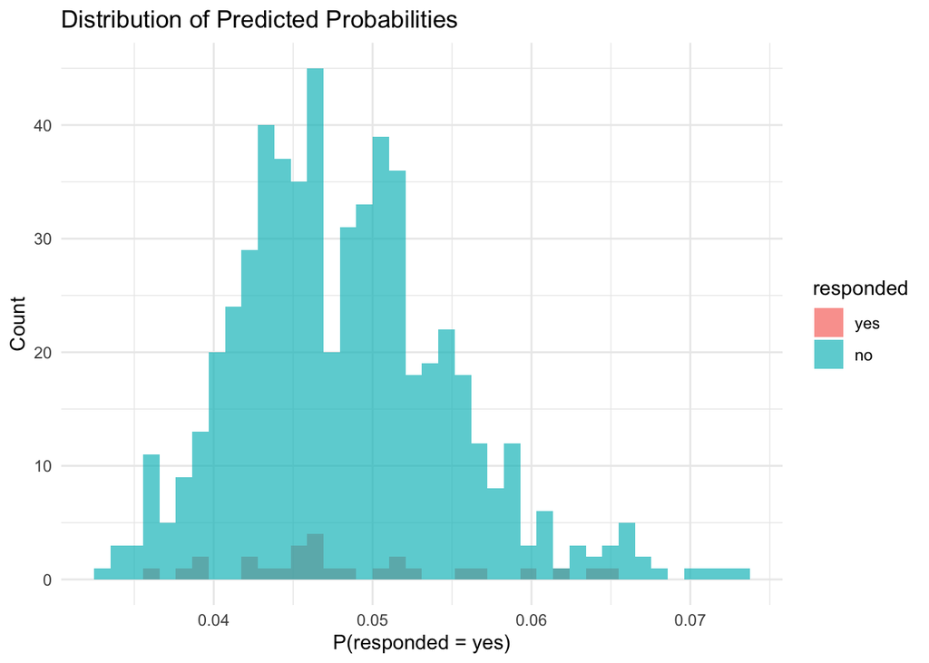

```r
library(tidymodels)
tidymodels_prefer()

mail_split <- initial_split(mail_data, prop = 0.80, strata = responded)
mail_train <- training(mail_split)
mail_test <- testing(mail_split)

mail_rec <- recipe(responded ~ ., data = mail_train) |>
  update_role(customer_id, new_role = "ID") |>
  step_impute_median(all_numeric_predictors()) |>
  step_log(income, avg_order_amt, recency_days, base = 10, offset = 1) |>
  step_normalize(all_numeric_predictors()) |>
  step_dummy(all_nominal_predictors()) |>
  step_zv(all_predictors())

lr_spec <- logistic_reg(penalty = 0.01, mixture = 1) |>
  set_engine("glmnet") |>
  set_mode("classification")

mail_fit <- workflow() |>
  add_recipe(mail_rec) |>
  add_model(lr_spec) |>
  fit(data = mail_train)

preds <- augment(mail_fit, new_data = mail_test)

# Distribution of predicted probabilities
ggplot(preds, aes(x = .pred_yes, fill = responded)) +
  geom_histogram(bins = 40, alpha = 0.7, position = "identity") +
  labs(
    title = "Distribution of Predicted Probabilities",
    x = "P(responded = yes)",
    y = "Count"
  ) +
  theme_minimal()
```

## 5.5 Q22 — Wald’s Test and Variable Selection

The video mentions that logistic regression uses **Wald’s tests** to evaluate whether individual predictors contribute meaningfully to the model.

1. In the Week 2 notebook, you used a **Lasso** penalty (`mixture = 1`). How does Lasso serve a similar purpose to Wald’s test — identifying which predictors are not useful?
2. Run the code below to extract the model coefficients. Which predictors were shrunk to exactly zero by the Lasso?
3. Based on the video’s explanation of what logistic regression coefficients represent (log odds ratios), interpret the sign of the `freq_12mo` coefficient in plain English.

```r
# Extract Lasso coefficients
mail_fit |>
  extract_fit_parsnip() |>
  tidy() |>
  filter(term != "(Intercept)") |>
  arrange(desc(abs(estimate)))
```

| term | estimate | penalty |
| --- | --- | --- |
| age | -0.10862627 | 0.01 |
| freq_12mo | -0.09379656 | 0.01 |
| income | 0.00000000 | 0.01 |
| recency_days | 0.00000000 | 0.01 |
| avg_order_amt | 0.00000000 | 0.01 |
| channel_direct_mail | 0.00000000 | 0.01 |
| channel_email | 0.00000000 | 0.01 |
| region_Northeast | 0.00000000 | 0.01 |
| region_South | 0.00000000 | 0.01 |
| region_West | 0.00000000 | 0.01 |

[output cut: 3 more lines]

## 5.6 Q23 — Synthesis: From Logs to Logistic Regression

This final question ties all four videos together.

Written question (3–5 sentences):

The four videos form a conceptual chain: **Logs → Odds → Odds Ratios → Logistic Regression**.

1. Explain in your own words how each step connects to the next:
   - Why do we take the **log** of odds (not just use odds directly)?
   - Why do we compare odds as a **ratio** rather than a difference?
   - How does the logit (log odds) become the linear predictor inside logistic regression?
2. In the context of the direct-mail campaign in `mail_data`, describe in one sentence what the logistic regression model is actually computing when it produces `.pred_yes = 0.08` for a specific customer.

### 5.6.1 Response

1. We take the log of the odds because it transforms probabilities into values that can be modeled with a linear relationship. Comparing odds as a ratio shows how much more or less likely one outcome is compared to another. Logistic regression uses the logit (log odds) as the linear predictor and then converts it back into a probability using the logistic function.
2. When the model predicts `.pred_yes = 0.08`, it is estimating that the customer has an **8% probability** of responding to the direct-mail campaign based on their characteristics.

# Summary Table

| Video | Key concept | R function |
| --- | --- | --- |
| Step 1-1 | Log isolates exponent | `log()`, `log10()`, `exp()` |
| Step 1-1 | Geometric mean | `exp(mean(log(x)))` |
| Step 1-2 | Probability → odds | `p / (1 - p)` |
| Step 1-2 | Odds → log(odds) | `log(p / (1 - p))` |
| Step 1-2 | Log(odds) → probability | `plogis()` |
| Step 1-3 | Odds ratio | `odds_a / odds_b` |
| Step 1-3 | Fisher’s exact test | `fisher.test()` |
| Step 1-3 | Chi-square test | `chisq.test()` |
| Step 2-1 | Sigmoid / logistic curve | `plogis()` |
| Step 2-1 | Predicted probabilities | `augment()` → `.pred_yes` |
| Step 2-1 | Coefficients as log(OR) | `tidy(extract_fit_parsnip())` |

# 6 Log Assignments

## 6.1 Setup

Run this chunk first — it loads the packages and recreates the direct-mail dataset used throughout the course.

```r
library(tidyverse)

# ── Recreate the direct-mail dataset ─────────────────────────────────────────
set.seed(123)
n <- 3000

mail_data <- tibble(
  customer_id = paste0("C", str_pad(1:n, 5, pad = "0")),
  age = round(rnorm(n, mean = 45, sd = 12)),
  income = round(rlnorm(n, meanlog = 10.8, sdlog = 0.6)),
  recency_days = round(rexp(n, rate = 1 / 60)),
  freq_12mo = rpois(n, lambda = 3),
  avg_order_amt = round(rlnorm(n, meanlog = 4.2, sdlog = 0.5), 2),
  channel = sample(
    c("email", "direct_mail", "digital"),
    n,
    replace = TRUE,
    prob = c(0.5, 0.3, 0.2)
  ),
  region = sample(
    c("West", "South", "Midwest", "Northeast"),
    n,
    replace = TRUE
  ),
  loyalty_tier = sample(
    c("Bronze", "Silver", "Gold", "Platinum"),
    n,
    replace = TRUE,
    prob = c(0.4, 0.3, 0.2, 0.1)
  ),
  responded = rbinom(
    n,
    1,
    prob = plogis(
      -3 +
        0.02 * (age - 45) +
        0.3 * log(income / 50000) +
        0.1 * freq_12mo -
        0.005 * recency_days
    )
  )
) |>
  mutate(
    income = if_else(runif(n) < 0.08, NA_real_, income),
    avg_order_amt = if_else(runif(n) < 0.05, NA_real_, avg_order_amt),
    responded = factor(responded, levels = c(1, 0), labels = c("yes", "no"))
  )

glimpse(mail_data)
```

```
Rows: 3,000
Columns: 10
$ customer_id   <chr> "C00001", "C00002", "C00003", "C00004", "C00005", "C0000…
$ age           <dbl> 38, 42, 64, 46, 47, 66, 51, 30, 37, 40, 60, 49, 50, 46, …
$ income        <dbl> 44793, 40269, 20560, 32261, 233070, 47933, 84804, 43883,…
$ recency_days  <dbl> 103, 102, 27, 115, 47, 106, 4, 62, 13, 21, 139, 100, 9, …
$ freq_12mo     <int> 4, 3, 0, 3, 1, 3, 5, 2, 1, 6, 1, 3, 3, 3, 6, 1, 1, 1, 6,…
$ avg_order_amt <dbl> 80.19, NA, 54.80, 46.49, 64.86, 78.43, 39.45, NA, 68.26,…
$ channel       <chr> "email", "digital", "digital", "email", "digital", "dire…
$ region        <chr> "West", "South", "Northeast", "Northeast", "Midwest", "W…
$ loyalty_tier  <chr> "Bronze", "Bronze", "Bronze", "Bronze", "Gold", "Silver"…
$ responded     <fct> no, no, yes, no, yes, yes, no, no, no, no, no, no, no, n…
```

# 7 Assignment L.1 — Dollar to Log

Customer `C00005` has an income of $233,070.

1. Convert this value to the **natural log**: `log(233070)`
2. Convert this value to **log base 10**: `log10(233070)`
3. Verify both results using R
4. In your own words, why does the recipe use `base = 10` rather than the natural log?

**Hint**

In R, `log(x)` computes the natural log ($\ln x$) and `log10(x)` computes log base 10. You can also write `log(x, base = 10)` — this is exactly what `step_log(..., base = 10)` uses internally.

```r
log(233070)
```

```
[1] 12.35909
```

```r
log10(233070)
```

```
[1] 5.367486
```

### 7.0.1 Response

1. The natural log and the base-10 log of 233,070 produce different values because they use different logarithm bases.
2. Both transformations compress the large income value into a smaller scale, making it easier to analyze and model.
3. The recipe uses `base = 10` because it is easier to interpret, but either base would work since the data are normalized afterward.

# 8 Assignment L.2 — Log Back to Dollar (Median and Mean)

The income variable was generated with `meanlog = 10.8` and `sdlog = 0.6`. These parameters describe the distribution of **log(income)**, not income itself.

1. Convert the log-scale **median** (10.8) back to dollars using `exp()`
2. Convert the log-scale **mean** (10.98) back to dollars using `exp()`
3. Verify these match the formulas from the Week 2 notebook:

$$\text{Median} = e^{\mu} = e^{10.8}$$

$$\text{Mean} = e^{\mu + \sigma^2/2} = e^{10.8 + 0.6^2/2}$$

4. Why is the mean higher than the median on the dollar scale?

**Hint**

`exp(x)` is the inverse of `log(x)`. If `log(income) = 10.8`, then `exp(10.8)` gives you income back in dollars. For the mean, compute `10.8 + 0.6^2 / 2` first, then apply `exp()`.

```r
# Median
exp(10.8)
```

```
[1] 49020.8
```

```r
# Mean
exp(10.98)
```

```
[1] 58688.55
```

```r
# Formula from the notebook
exp(10.8)
```

```
[1] 49020.8
```

```r
exp(10.8 + 0.6^2 / 2)
```

```
[1] 58688.55
```

### 8.0.1 Response

1. Using `exp(10.8)` converts the log-scale median back into dollars.
2. Using `exp(10.98)` converts the log-scale mean back into dollars.
3. The calculated values match the formulas because `exp()` is the inverse of the logarithm.
4. The mean is higher than the median because the income distribution is right-skewed. A small number of customers with very high incomes increase the average more than the median.

# 9 Assignment L.3 — Geometric Standard Deviation

The **geometric standard deviation (GSD)** describes the typical spread of income around the median on the original dollar scale.

$$\text{GSD} = e^{\sigma} = e^{0.6}$$

1. Compute the GSD using `exp(0.6)`
2. Using the median income from L.2 (~$49,021), compute the typical range:
   - Lower bound: `median_income / GSD`
   - Upper bound: `median_income * GSD`
3. Verify this matches the shaded green band in the Week 2 plot (~$26,935 to ~$89,218)
4. Interpret this range in plain English: what does it tell a marketer about the “typical” customer in this dataset?

**Hint**

Unlike the regular standard deviation (which adds and subtracts), the GSD **multiplies and divides** because we are on a multiplicative (log) scale.

```r
# Geometric Standard Deviation
GSD <- exp(0.6)
GSD
```

```
[1] 1.822119
```

```r
median_income <- 49021

# Lower and upper bounds
median_income / GSD
```

```
[1] 26903.3
```

```r
median_income * GSD
```

```
[1] 89322.09
```

### 9.0.1 Response

# 10 Assignment L.4 — Confirm with Real Data

Now verify the theoretical values from L.2 and L.3 against the actual `mail_data` dataset.

1. Compute the **median** and **mean** of `income`, removing `NA`s with `na.rm = TRUE`. How close are they to the theoretical values?
2. Create a new column called `log_income` using `mutate()` and `log()`. What are the median and mean of `log_income`?
3. Apply `exp()` to the median and mean of `log_income`. Do you recover the original dollar-scale values? Explain why or why not.

**Hint**

Use `summarise()` with `median()` and `mean()` to compute summary statistics. The theoretical and empirical values may differ slightly because `mail_data` is a finite random sample — not the infinite population the parameters describe.

```r
# Step 1
mail_data |>
  summarise(
    median_income = median(income, na.rm = TRUE),
    mean_income = mean(income, na.rm = TRUE)
  )
```

| median_income | mean_income |
| --- | --- |
| 49331.5 | 58349.86 |

```r
# Step 2
mail_data |>
  mutate(log_income = log(income)) |>
  summarise(
    median_log = median(log_income, na.rm = TRUE),
    mean_log = mean(log_income, na.rm = TRUE)
  )
```

| median_log | mean_log |
| --- | --- |
| 10.80632 | 10.79787 |

```r
# Step 3
exp(10.8)
```

```
[1] 49020.8
```

```r
exp(10.8 + 0.6^2 / 2)
```

```
[1] 58688.55
```

### 10.0.1 Response

1. The median and mean of the actual `income` variable are very close to the theoretical values, although they may differ slightly because the dataset is a random sample.
2. The median and mean of `log_income` are also close to the theoretical values used to generate the data.
3. Applying `exp()` converts the log-scale values back to the original dollar scale. The values are close to the original summaries, but they are not exactly the same because the data are based on a finite sample and include random variation.

# 11 Assignment L.5 — Base 10 vs. Natural Log

Your recipe uses `step_log(..., base = 10)`. Does the choice of base actually matter for modeling?

1. For income values of $10,000, $100,000, and $1,000,000, compute both `log()` (natural) and `log10()` for each value
2. Present the results as a tibble with columns: `income`, `log_natural`, `log_base10`
3. Divide `log_natural` by `log_base10` for each row. What constant do you get? (Hint: this constant is `log(10)`)
4. Since the two columns differ only by a constant, does it matter which base we use for preprocessing? Explain why or why not in terms of what `step_normalize()` does afterward.

**Hint**

`log(10)` ≈ 2.303. Multiplying or dividing by a constant shifts and scales values — but `step_normalize()` centers and scales anyway, so any constant difference between bases gets absorbed.

```r
# Step 1 & 2
logs_tbl <- tibble(
  income = c(10000, 100000, 1000000)
) |>
  mutate(
    log_natural = log(income),
    log_base10 = log10(income)
  )

logs_tbl
```

| income | log_natural | log_base10 |
| --- | --- | --- |
| 1e+04 | 9.21034 | 4 |
| 1e+05 | 11.51293 | 5 |
| 1e+06 | 13.81551 | 6 |

```r
# Step 3
logs_tbl |>
  mutate(ratio = log_natural / log_base10)
```

| income | log_natural | log_base10 | ratio |
| --- | --- | --- | --- |
| 1e+04 | 9.21034 | 4 | 2.302585 |
| 1e+05 | 11.51293 | 5 | 2.302585 |
| 1e+06 | 13.81551 | 6 | 2.302585 |

### 11.0.1 Response

1. The natural log and base-10 log produce different numerical values, but they describe the same relationship.
2. Dividing the natural log by the base-10 log produces a constant of approximately **2.3026**, which is equal to `log(10)`.
3. Since the two log scales differ only by a constant, either base can be used for preprocessing.

## 11.1 After `step_normalize()`, the values are centered and scaled, so the difference between using natural log and base-10 log is effectively removed.

# 12 Summary

| Assignment | Key operation | R function |
| --- | --- | --- |
| L.1 | Dollar → log | `log()`, `log10()` |
| L.2 | Log → dollar (median & mean) | `exp()` |
| L.3 | Geometric standard deviation | `exp(sdlog)` |
| L.4 | Empirical vs. theoretical values | `mutate()`, `summarise()` |
| L.5 | Base 10 vs. natural log | `log()` / `log10()` ratio |

## 12.1 ✏️ Exercise 3.1

Change `prop` to `0.70` and re-run the split. How many records move from training to test? How does the response rate change?

```r
library(tidyverse)
library(tidymodels)
mail_split <- initial_split(
  mail_data,
  prop = 0.70,
  strata = responded
)

mail_train <- training(mail_split)
mail_test <- testing(mail_split)

cat("Training rows:", nrow(mail_train), "\n")
```

```
Training rows: 2100
```

```r
cat("Test rows:", nrow(mail_test), "\n")
```

```
Test rows: 900
```

```r
bind_rows(
  mail_train |> count(responded) |> mutate(set = "train"),
  mail_test |> count(responded) |> mutate(set = "test")
) |>
  group_by(set) |>
  mutate(pct = n / sum(n))
```

| responded | n | set | pct |
| --- | --- | --- | --- |
| yes | 100 | train | 0.04761905 |
| no | 2000 | train | 0.95238095 |
| yes | 42 | test | 0.04666667 |
| no | 858 | test | 0.95333333 |

### 12.1.1 Response

## 12.2 Changing the split from 80/20 to 70/30 moved more observations into the testing dataset while reducing the size of the training dataset. Because stratified sampling was used, the response rate remained very similar in both datasets, ensuring that both sets represent the original distribution of responders.

# 13 Preprocessing Exercises

## 13.1 ✏️ Exercise 8.1 — Alternative Imputation

Replace `step_impute_median()` with `step_impute_mean()`. Re-prep the recipe and compare the imputed values. Which would you prefer for `income` and why?

```r
mail_rec_mean <-
  recipe(responded ~ ., data = mail_train) |>
  update_role(customer_id, new_role = "ID") |>
  step_impute_mean(all_numeric_predictors()) |>
  step_log(income, avg_order_amt, recency_days, base = 10, offset = 1) |>
  step_normalize(all_numeric_predictors()) |>
  step_dummy(all_nominal_predictors()) |>
  step_zv(all_predictors())

mail_prep_mean <- prep(mail_rec_mean)

tidy(mail_prep_mean, number = 1)
```

| terms | value | id |
| --- | --- | --- |
| age | 45.23286 | impute_mean_VGFuA |
| income | 57218.75543 | impute_mean_VGFuA |
| recency_days | 59.42333 | impute_mean_VGFuA |
| freq_12mo | 3.00000 | impute_mean_VGFuA |
| avg_order_amt | 75.28505 | impute_mean_VGFuA |

### 13.1.1 Response

Using `step_impute_mean()` replaces missing values with the average instead of the median. For the `income` variable, I would still prefer median imputation because income is right-skewed and the median is less affected by very high-income values.

## 13.2 ✏️ Exercise 8.2 — Different Encoding

`loyalty_tier` is ordinal (Bronze < Silver < Gold < Platinum). Replace `step_dummy()` with `step_ordinalscore()` for `loyalty_tier` only. Does this change the number of columns in the baked data?

```r
mail_train_ord <- mail_train |>
  mutate(
    loyalty_tier = factor(
      loyalty_tier,
      levels = c("Bronze", "Silver", "Gold", "Platinum"),
      ordered = TRUE
    )
  )

mail_rec_ord <-
  recipe(responded ~ ., data = mail_train_ord) |>
  update_role(customer_id, new_role = "ID") |>
  step_impute_median(all_numeric_predictors()) |>
  step_log(income, avg_order_amt, recency_days, base = 10, offset = 1) |>
  step_normalize(all_numeric_predictors()) |>
  step_ordinalscore(loyalty_tier) |>
  step_dummy(all_nominal_predictors()) |>
  step_zv(all_predictors())

mail_prep_ord <- prep(mail_rec_ord)

bake(mail_prep_ord, new_data = NULL)
```

| customer_id | age | income | recency_days | freq_12mo | avg_order_amt | loyalty_tier | responded | channel_direct_mail | channel_email | region_Northeast | region_South | region_West |
| --- | --- | --- | --- | --- | --- | --- | --- | --- | --- | --- | --- | --- |
| C00001 | -0.59957541 | -1.291140e-01 | 0.921328884 | 0.62648477 | 0.3824187639 | 1 | no | 0 | 1 | 0 | 0 | 1 |
| C00003 | 1.55572234 | -1.505721e+00 | -0.226583158 | -1.71239171 | -0.4019459086 | 1 | yes | 0 | 0 | 1 | 0 | 0 |
| C00004 | 0.06359313 | -7.093031e-01 | 1.016857372 | 0.04176565 | -0.7392161782 | 1 | no | 0 | 1 | 1 | 0 | 0 |
| C00005 | 0.14648919 | 2.786590e+00 | 0.244935659 | -1.12767259 | -0.0552580715 | 3 | yes | 0 | 0 | 0 | 0 | 0 |
| C00007 | 0.47807346 | 9.992869e-01 | -1.733674330 | 1.21120390 | -1.0748086420 | 1 | no | 0 | 1 | 0 | 0 | 0 |
| C00008 | -1.26274395 | -1.653986e-01 | 0.482825633 | -0.54295347 | -0.0242087170 | 1 | no | 0 | 1 | 0 | 1 | 0 |
| C00010 | -0.43378328 | -2.560439e-02 | -0.437553818 | 1.79592302 | -0.5183222737 | 3 | no | 0 | 1 | 0 | 0 | 1 |
| C00011 | 1.22413807 | 1.477067e+00 | 1.181367097 | -1.12767259 | -1.0945500766 | 3 | no | 0 | 1 | 0 | 0 | 0 |
| C00012 | 0.31228133 | -5.038924e-01 | 0.895722899 | 0.04176565 | 0.5035271227 | 2 | no | 1 | 0 | 0 | 1 | 0 |
| C00013 | 0.39517739 | -1.782430e+00 | -1.127303160 | 0.04176565 | 3.1742032306 | 1 | no | 0 | 1 | 0 | 0 | 0 |

[output cut: 2090 more lines]

### 13.2.1 Response

Using `step_ordinalscore()` converts the ordered loyalty tiers into a single numeric variable instead of creating multiple dummy variables. This reduces the number of columns in the baked dataset while preserving the natural order of Bronze, Silver, Gold, and Platinum.

## 13.3 ✏️ Exercise 8.3 — Interaction Term

Add an interaction between `freq_12mo` and `log10(income)` using `step_interact()`. What is the marketing intuition for this interaction?

```r
mail_rec_interact <-
  recipe(responded ~ ., data = mail_train) |>
  update_role(customer_id, new_role = "ID") |>
  step_impute_median(all_numeric_predictors()) |>
  step_log(
    income,
    avg_order_amt,
    recency_days,
    base = 10,
    offset = 1
  ) |>
  step_interact(~ freq_12mo:income) |>
  step_normalize(all_numeric_predictors()) |>
  step_dummy(all_nominal_predictors()) |>
  step_zv(all_predictors())

mail_prep_interact <- prep(mail_rec_interact)

bake(mail_prep_interact, new_data = NULL)
```

| customer_id | age | income | recency_days | freq_12mo | avg_order_amt | responded | freq_12mo_x_income | channel_direct_mail | channel_email | region_Northeast | region_South | region_West | loyalty_tier_Gold | loyalty_tier_Platinum | loyalty_tier_Silver |
| --- | --- | --- | --- | --- | --- | --- | --- | --- | --- | --- | --- | --- | --- | --- | --- |
| C00001 | -0.59957541 | -1.291140e-01 | 0.921328884 | 0.62648477 | 0.3824187639 | no | 6.038682e-01 | 0 | 1 | 0 | 0 | 1 | 0 | 0 | 0 |
| C00003 | 1.55572234 | -1.505721e+00 | -0.226583158 | -1.71239171 | -0.4019459086 | yes | -1.696361e+00 | 0 | 0 | 1 | 0 | 0 | 0 | 0 | 0 |
| C00004 | 0.06359313 | -7.093031e-01 | 1.016857372 | 0.04176565 | -0.7392161782 | no | -2.405385e-02 | 0 | 1 | 1 | 0 | 0 | 0 | 0 | 0 |
| C00005 | 0.14648919 | 2.786590e+00 | 0.244935659 | -1.12767259 | -0.0552580715 | yes | -1.032747e+00 | 0 | 0 | 0 | 0 | 0 | 1 | 0 | 0 |
| C00007 | 0.47807346 | 9.992869e-01 | -1.733674330 | 1.21120390 | -1.0748086420 | no | 1.350286e+00 | 0 | 1 | 0 | 0 | 0 | 0 | 0 | 0 |
| C00008 | -1.26274395 | -1.653986e-01 | 0.482825633 | -0.54295347 | -0.0242087170 | no | -5.484502e-01 | 0 | 1 | 0 | 1 | 0 | 0 | 0 | 0 |
| C00010 | -0.43378328 | -2.560439e-02 | -0.437553818 | 1.79592302 | -0.5183222737 | no | 1.772845e+00 | 0 | 1 | 0 | 0 | 1 | 1 | 0 | 0 |
| C00011 | 1.22413807 | 1.477067e+00 | 1.181367097 | -1.12767259 | -1.0945500766 | no | -1.072520e+00 | 0 | 1 | 0 | 0 | 0 | 1 | 0 | 0 |
| C00012 | 0.31228133 | -5.038924e-01 | 0.895722899 | 0.04176565 | 0.5035271227 | no | -5.337518e-03 | 1 | 0 | 0 | 1 | 0 | 0 | 0 | 1 |
| C00013 | 0.39517739 | -1.782430e+00 | -1.127303160 | 0.04176565 | 3.1742032306 | no | -1.218336e-01 | 0 | 1 | 0 | 0 | 0 | 0 | 0 | 0 |

[output cut: 2090 more lines]

### 13.3.1 Response

The interaction term allows the relationship between purchase frequency and campaign response to depend on customer income. From a marketing perspective, customers with higher incomes who purchase more frequently may respond differently to a campaign than customers with lower incomes and the same purchase frequency.

## 13.4 ✏️ Exercise 8.4 — Remove a Step

Remove `step_normalize()` from the recipe, retrain the Lasso, and compare `roc_auc` before and after. What happens to model performance?

```r
mail_rec_no_norm <-
  recipe(responded ~ ., data = mail_train) |>
  update_role(customer_id, new_role = "ID") |>
  step_impute_median(all_numeric_predictors()) |>
  step_log(
    income,
    avg_order_amt,
    recency_days,
    base = 10,
    offset = 1
  ) |>
  step_dummy(all_nominal_predictors()) |>
  step_zv(all_predictors())

mail_wf_no_norm <-
  workflow() |>
  add_recipe(mail_rec_no_norm) |>
  add_model(lr_spec)

mail_fit_no_norm <-
  fit(mail_wf_no_norm, data = mail_train)

preds_no_norm <-
  augment(mail_fit_no_norm, new_data = mail_test)

preds_no_norm |>
  roc_auc(truth = responded, .pred_yes)
```

[output not shown]

### 13.4.1 Response

Removing `step_normalize()` may reduce model performance because Lasso regression is sensitive to differences in variable scales. Normalization helps place predictors on the same scale, allowing the penalty to be applied fairly across all variables.

## 13.5 ✏️ Exercise 8.5 — Stratification Check

The split used `strata = responded`. Remove stratification and re-split five times. Calculate the standard deviation of the response rate in the test sets. Does stratification reduce variance?

```r
set.seed(123)

test_rates <- map_dbl(1:5, function(i) {
  split_no_strata <- initial_split(mail_data, prop = 0.80)
  test_no_strata <- testing(split_no_strata)

  mean(test_no_strata$responded == "yes")
})

test_rates

sd(test_rates)
```

[output not shown]

### 13.5.1 Response

Without stratification, the response rate in the test set can vary more from one random split to another. Stratified sampling helps keep the proportion of responders consistent across the training and testing datasets, reducing the variability of the response rate.

## 13.6 ✏️ Exercise 8.6 — Data Leakage

Prep the recipe correctly using `mail_train`, then bake `mail_test`. Next, incorrectly prep the same recipe using `mail_test`. Compare the normalization statistics for `income`. Why is the second approach considered data leakage?

```r
# Correct: prep using the training data
mail_prep_train <- prep(mail_rec, training = mail_train)

# Apply to the test data
bake(mail_prep_train, new_data = mail_test)

# Incorrect: prep using the test data
mail_prep_test <- prep(mail_rec, training = mail_test)

# Compare normalization statistics
tidy(mail_prep_train, number = 3)
tidy(mail_prep_test, number = 3)
```

[output not shown]

### 13.6.1 Response

Preparing the recipe with the training data and then applying it to the test data prevents information from leaking into the model. Preparing the recipe using the test data causes the normalization statistics to be learned from the test set, which is considered data leakage because it uses information that should remain unseen until model evaluation.

## 13.7 ✏️ Exercise 8.7 — Inspecting a Recipe

Use `tidy(mail_prep)` to list the recipe steps. Then inspect the imputation values and normalization statistics using `tidy(mail_prep, number = 1)` and `tidy(mail_prep, number = 3)`. What values were learned during `prep()`?

```r
# List all recipe steps
tidy(mail_prep)

# Inspect imputation values
tidy(mail_prep, number = 1)

# Inspect normalization statistics
tidy(mail_prep, number = 3)
```

[output not shown]

### 13.7.1 Response

The `tidy()` function lists each preprocessing step that was learned during `prep()`. The first step shows the values used to impute missing data, while the third step shows the means and standard deviations learned for normalization. These values were estimated from the training data and are later applied to new data during baking.

## 13.8 ✏️ Exercise 8.8 — Variable Roles

Remove `update_role(customer_id, new_role = "ID")` from the recipe and re-prep it. What happens to `customer_id` in the baked data? Why should an ID variable not be used as a predictor?

```r
mail_rec_no_id <-
  recipe(responded ~ ., data = mail_train) |>
  step_impute_median(all_numeric_predictors()) |>
  step_log(
    income,
    avg_order_amt,
    recency_days,
    base = 10,
    offset = 1
  ) |>
  step_normalize(all_numeric_predictors()) |>
  step_dummy(all_nominal_predictors()) |>
  step_zv(all_predictors())

mail_prep_no_id <- prep(mail_rec_no_id)

bake(mail_prep_no_id, new_data = NULL)
```

[output not shown]

### 13.8.1 Response

Without assigning `customer_id` the ID role, it is treated as a predictor and appears in the baked data. Since customer IDs are only unique identifiers and contain no meaningful information about customer behavior, they should not be used as predictors because they can add unnecessary complexity without improving model performance.

# 14 Summary

| Concept | Function | Key Argument |
| --- | --- | --- |
| Data split | `initial_split()` | `prop`, `strata` |
| Training set | `training()` | — |
| Test set | `testing()` | — |
| Define recipe | `recipe()` | formula, `data = train` |
| Log transform | `step_log()` | `base`, `offset` |
| Median impute | `step_impute_median()` | selector |
| Normalize | `step_normalize()` | selector |
| Dummy encode | `step_dummy()` | `all_nominal_predictors()` |
| Estimate steps | `prep()` | `training = train` |
| Apply steps | `bake()` | `new_data = test` |
| Bundle recipe + model | `workflow()` | — |

# 15 Appendix

## 15.1 Published Report

https://tarana7.github.io/m04-recipes/

## 15.2 GitHub Repository

https://github.com/tarana7/m04-recipes